# Final Exam Modul 12

Johannes Schwietering

2024-06-22

# How to predict readmission for diabetic patients?

## Introduction

The dataset titled “Diabetes 130-US Hospitals for Years 1999-2008” from Strack et al., published in 2014 in the journal BioMed Research International, serves as the foundation for my research.

**Primary Research Question**

- **Is the measurement of HbA1c associated with a reduction in readmission rates for individuals admitted to a hospital?**

**Secondary Research Questions**

- Which factors best predict patient readmission?
- What additional insights can be derived from the data? (This broad question allows for the application of various analytical methods.)

**Personal Interest**

The challenge of predicting hospital readmissions is of personal relevance to me, as a family member has diabetes. This research holds significant personal importance and drives my motivation to uncover meaningful insights.

Citation: “Beata Strack, Jonathan P. DeShazo, Chris Gennings, Juan L. Olmo, Sebastian Ventura, Krzysztof J. Cios, and John N. Clore, “Impact of HbA1c Measurement on Hospital Readmission Rates: Analysis of 70,000 Clinical Database Patient Records,” BioMed Research International, vol. 2014, Article ID 781670, 11 pages, 2014.”

## Method

To answer the research questions, the following steps will be conducted:

1. **Providing an Overview of the Dataset**
2. **Cleaning the Data**
3. **Preprocessing the Data**
4. **Feature Selection with Information Gain**
5. **Multinomial Logistic Regression (Without Covariates)**
6. **Logistic Regression with Covariates**
7. **Random Forest V1**
8. **Random Forest V2**
9. **Small Excursus to Unsupervised Learning**

## Getting an Overview

To get an overview, I will examine the structure and dimensions of the dataset, as well as the independent and dependent variables (readmission).

```r
#Load Data
diabetes_data <- read.csv("diabetic_data.csv")

# Getting an Overview
# Structure of the dataset
str(diabetes_data)
```

```
## 'data.frame':    101766 obs. of  50 variables:
##  $ encounter_id            : int  2278392 149190 64410 500364 16680 35754 55842 63768 12522 15738 ...
##  $ patient_nbr             : int  8222157 55629189 86047875 82442376 42519267 82637451 84259809 114882984 48330783 63555939 ...
##  $ race                    : chr  "Caucasian" "Caucasian" "AfricanAmerican" "Caucasian" ...
##  $ gender                  : chr  "Female" "Female" "Female" "Male" ...
##  $ age                     : chr  "[0-10)" "[10-20)" "[20-30)" "[30-40)" ...
##  $ weight                  : chr  "?" "?" "?" "?" ...
##  $ admission_type_id       : int  6 1 1 1 1 2 3 1 2 3 ...
##  $ discharge_disposition_id: int  25 1 1 1 1 1 1 1 1 3 ...
##  $ admission_source_id     : int  1 7 7 7 7 2 2 7 4 4 ...
##  $ time_in_hospital        : int  1 3 2 2 1 3 4 5 13 12 ...
##  $ payer_code              : chr  "?" "?" "?" "?" ...
##  $ medical_specialty       : chr  "Pediatrics-Endocrinology" "?" "?" "?" ...
##  $ num_lab_procedures      : int  41 59 11 44 51 31 70 73 68 33 ...
##  $ num_procedures          : int  0 0 5 1 0 6 1 0 2 3 ...
```

[output cut: 36 more lines]

```r
dim(diabetes_data)
```

```
## [1] 101766     50
```

```r
kable(head(diabetes_data), format = "html", table.attr = 'class="table table-striped table-hover"')
```

| encounter_id | patient_nbr | race | gender | age | weight | admission_type_id | discharge_disposition_id | admission_source_id | time_in_hospital | payer_code | medical_specialty | num_lab_procedures | num_procedures | num_medications | number_outpatient | number_emergency | number_inpatient | diag_1 | diag_2 | diag_3 | number_diagnoses | max_glu_serum | A1Cresult | metformin | repaglinide | nateglinide | chlorpropamide | glimepiride | acetohexamide | … |
| --- | --- | --- | --- | --- | --- | --- | --- | --- | --- | --- | --- | --- | --- | --- | --- | --- | --- | --- | --- | --- | --- | --- | --- | --- | --- | --- | --- | --- | --- | --- |
| 2278392 | 8222157 | Caucasian | Female | [0-10) | ? | 6 | 25 | 1 | 1 | ? | Pediatrics-Endocrinology | 41 | 0 | 1 | 0 | 0 | 0 | 250.83 | ? | ? | 1 | None | None | No | No | No | No | No | No | … |
| 149190 | 55629189 | Caucasian | Female | [10-20) | ? | 1 | 1 | 7 | 3 | ? | ? | 59 | 0 | 18 | 0 | 0 | 0 | 276 | 250.01 | 255 | 9 | None | None | No | No | No | No | No | No | … |
| 64410 | 86047875 | AfricanAmerican | Female | [20-30) | ? | 1 | 1 | 7 | 2 | ? | ? | 11 | 5 | 13 | 2 | 0 | 1 | 648 | 250 | V27 | 6 | None | None | No | No | No | No | No | No | … |
| 500364 | 82442376 | Caucasian | Male | [30-40) | ? | 1 | 1 | 7 | 2 | ? | ? | 44 | 1 | 16 | 0 | 0 | 0 | 8 | 250.43 | 403 | 7 | None | None | No | No | No | No | No | No | … |
| 16680 | 42519267 | Caucasian | Male | [40-50) | ? | 1 | 1 | 7 | 1 | ? | ? | 51 | 0 | 8 | 0 | 0 | 0 | 197 | 157 | 250 | 5 | None | None | No | No | No | No | No | No | … |
| 35754 | 82637451 | Caucasian | Male | [50-60) | ? | 2 | 1 | 2 | 3 | ? | ? | 31 | 6 | 16 | 0 | 0 | 0 | 414 | 411 | 250 | 9 | None | None | No | No | No | No | No | No | … |

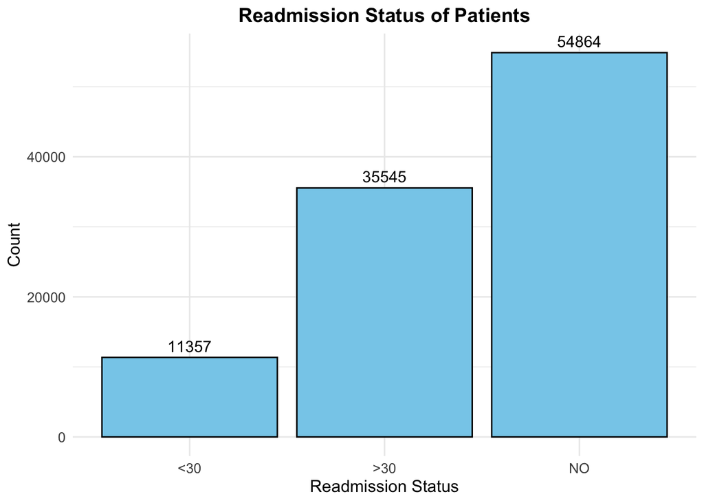

```r
# Create a bar plot for the readmitted variable
bar_plot <- ggplot(diabetes_data, aes(x = readmitted)) +
  geom_bar(fill = "skyblue", color = "black") +
  labs(title = "Readmission Status of Patients",
       x = "Readmission Status",
       y = "Count") +
  theme_minimal() +
  geom_text(stat='count', aes(label=..count..), vjust=-0.5, color="black", size=4) +
  theme(
    plot.title = element_text(hjust = 0.5, size = 14, face = "bold"),
    axis.title.x = element_text(size = 12),
    axis.title.y = element_text(size = 12),
    axis.text.x = element_text(size = 10),
    axis.text.y = element_text(size = 10)
  )

# Plot anzeigen
print(bar_plot)
```

### Learnings from the Overview

- Large dataset with over 100,000 encounters.
- Dependent variable is called “readmission.”
- Main independent variable is called “A1Cresult.”
- Overview of further independent variables.
- Majority of patients were not readmitted.

### Understanding the focus on encounter vs. patients

```r
# how many encounters are there?
num_unique_encounters <- length(unique(diabetes_data$encounter_id))
print(paste("Number of unique encounters:", num_unique_encounters))
```

```
## [1] "Number of unique encounters: 101766"
```

```r
# Number of unique patients
num_unique_patients <- length(unique(diabetes_data$patient_nbr))
print(paste("Number of unique patients:", num_unique_patients))
```

```
## [1] "Number of unique patients: 71518"
```

```r
# Count the number of occurrences of each patient_nbr
patient_counts <- table(diabetes_data$patient_nbr)

# Identify patient_nbr that are unique (appear only once)
unique_patient_nbr <- names(patient_counts[patient_counts == 1])

# Create a data frame excluding rows with unique patient_nbr
df_non_unique_patients <- diabetes_data[!(diabetes_data$patient_nbr %in% unique_patient_nbr), ]
readmission_status_non_unique <- table(df_non_unique_patients$readmitted)
cat("Readmission status for non-unique patients:\n")
```

```
## Readmission status for non-unique patients:
```

```r
print(readmission_status_non_unique)
```

```
##
##   <30   >30    NO
##  9191 25667 12163
```

```r
# Create a data frame only containing rows with unique patient_nbr
df_unique_patients <- diabetes_data[diabetes_data$patient_nbr %in% unique_patient_nbr, ]

readmission_status_unique <- table(df_unique_patients$readmitted)
cat("Readmission status for unique patients:\n")
```

```
## Readmission status for unique patients:
```

```r
print(readmission_status_unique)
```

```
##
##   <30   >30    NO
##  2166  9878 42701
```

```r
# Print the number of rows in each data frame to verify
cat("Number of rows in df_non_unique_patients:", nrow(df_non_unique_patients), "\n")
```

```
## Number of rows in df_non_unique_patients: 47021
```

```r
cat("Number of rows in df_unique_patients:", nrow(df_unique_patients), "\n")
```

```
## Number of rows in df_unique_patients: 54745
```

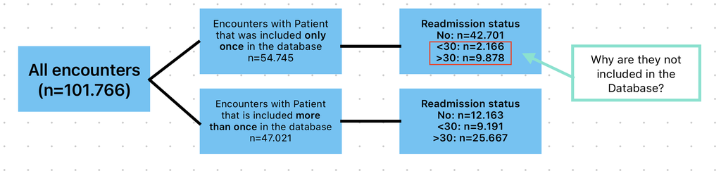

Understanding the “Encounters” and “Patient” Variable.

### Additional Learnings

- The observations in the dataset are encounters and not individual patients.
- Patients can be included multiple times. While the majority is included only once, some patients are included up to 40 times.
- About 12,000 patients were readmitted but are only included in the dataset once. This raises concerns about the data quality.

## Cleaning and preprocessing the data

### Missing Values

As shown in the table below, most of the variables have no missing values. However, some variables contain a higher number of missing values, and the following decisions were made on how to deal with those:

- The variables `weight`, `payer_code`, `medical_specialty`, and `diag_3` are all excluded as they are not needed for the analysis.
- `race` is important, and therefore I decided to delete all rows with missing values for `race`.

```r
# Replacing "?" with NA
diabetes_data[diabetes_data == "?"] <- NA

# Calculate the percentage of missing values for each attribute
missing_values <-
  sapply(diabetes_data, function(x) sum(is.na(x)) / length(x) * 100)

# Create a data frame with the results
missing_values_df <- data.frame(
  attribute = names(missing_values),
  missing_percentage = missing_values
)

# Filter the data frame to include only variables with missing percentage > 0
missing_values_filtered <- missing_values_df[missing_values_df$missing_percentage > 0, ]

# Add a row for "All other Variables"
all_others_row <- data.frame(
  attribute = "All other Variables",
  missing_percentage = 0
)

# Combine the filtered data frame with the "All other Variables" row
final_missing_values_df <- rbind(missing_values_filtered, all_others_row)
final_missing_values_df$missing_percentage <- round(final_missing_values_df$missing_percentage, 2)
rownames(final_missing_values_df) <- NULL

# Print the resulting data frame
print(final_missing_values_df)
```

```
##             attribute missing_percentage
## 1                race               2.23
## 2              weight              96.86
## 3          payer_code              39.56
## 4   medical_specialty              49.08
## 5              diag_1               0.02
## 6              diag_2               0.35
## 7              diag_3               1.40
## 8 All other Variables               0.00
```

```r
# Delete columns weight, payer:code, medical_specialty and diag_3
diabetes_data <- diabetes_data[, !(colnames(diabetes_data) %in% c("weight", "payer_code", "medical_specialty", "diag_3"))]

# Delete all rows where the variable "race" is NA
diabetes_data <- diabetes_data[!is.na(diabetes_data$race), ]
```

### Handling Outliers

However, there are a number of variables for which the handling of outliers must be decided. I will visually check for outliers in the following variables by creating boxplots:

- `time_in_hospital`
- `num_lab_procedures`
- `num_medications`
- `number_diagnoses`

After inspecting the boxplots, the decision was made to replace outliers with NA.

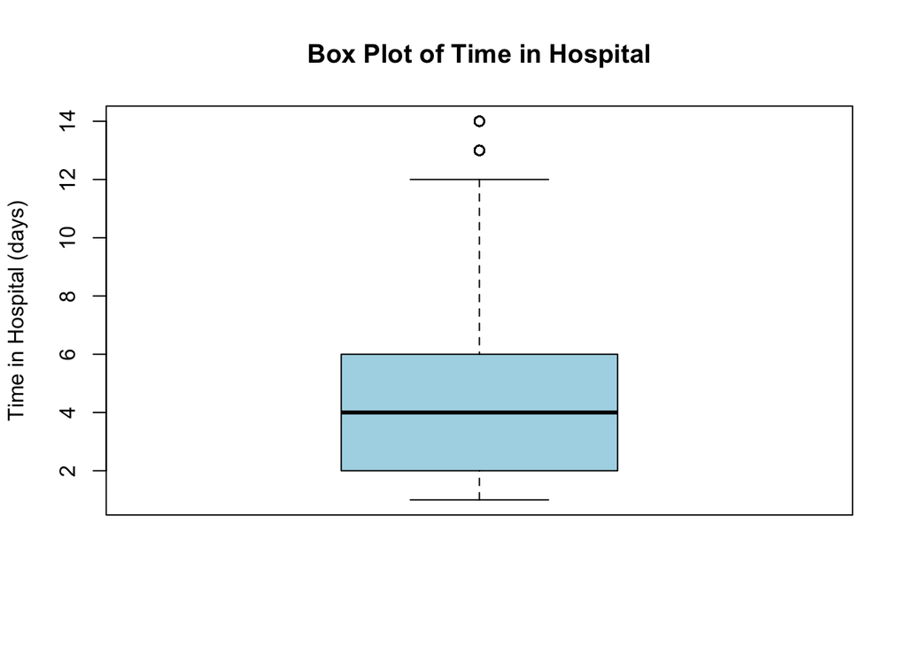

```r
# Box plot for time_in_hospital
boxplot(diabetes_data$time_in_hospital,
        main = "Box Plot of Time in Hospital",
        ylab = "Time in Hospital (days)",
        col = "lightblue")
```

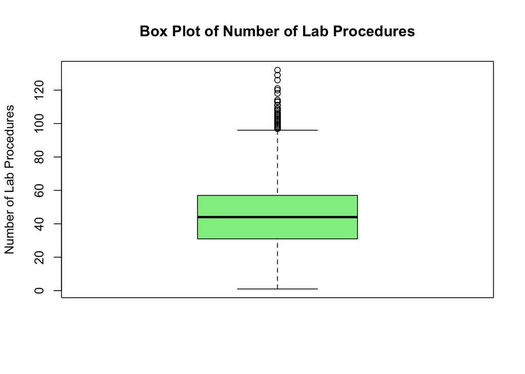

```r
# Box plot for num_lab_procedures
boxplot(diabetes_data$num_lab_procedures,
        main = "Box Plot of Number of Lab Procedures",
        ylab = "Number of Lab Procedures",
        col = "lightgreen")
```

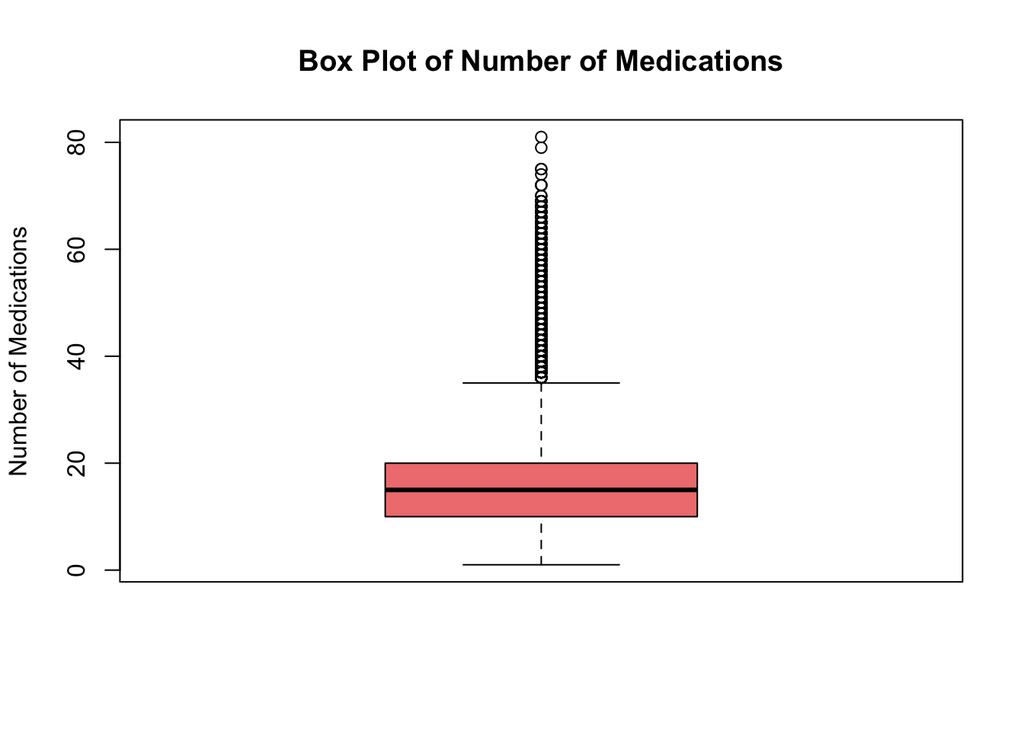

```r
# Box plot for num_medications
boxplot(diabetes_data$num_medications,
        main = "Box Plot of Number of Medications",
        ylab = "Number of Medications",
        col = "lightcoral")
```

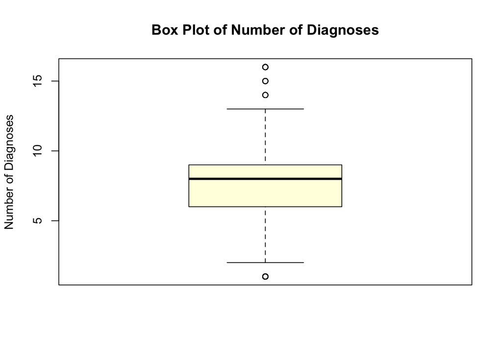

```r
# Box plot for number_diagnoses
boxplot(diabetes_data$number_diagnoses,
        main = "Box Plot of Number of Diagnoses",
        ylab = "Number of Diagnoses",
        col = "lightyellow")
```

```r
# Define and apply a function for IQR based outlier detection and replace the detected outliers function to replace outliers with NA
replace_outliers_with_NA <- function(x) {
  Q1 <- quantile(x, 0.25, na.rm = TRUE)
  Q3 <- quantile(x, 0.75, na.rm = TRUE)
  IQR <- Q3 - Q1
  lower_bound <- Q1 - 1.5 * IQR
  upper_bound <- Q3 + 1.5 * IQR

  x[x < lower_bound | x > upper_bound] <- NA
  return(x)
}

# List of columns to apply the function to
columns_to_check <- c("time_in_hospital", "num_lab_procedures", "num_medications", "number_diagnoses")

# Apply the function only to the specified columns
diabetes_data[columns_to_check] <- lapply(diabetes_data[columns_to_check], replace_outliers_with_NA)

# Check the summary to verify the changes
summary(diabetes_data[columns_to_check])
```

```
##  time_in_hospital num_lab_procedures num_medications number_diagnoses
##  Min.   : 1.000   Min.   : 1.00      Min.   : 1.00   Min.   : 2.000
##  1st Qu.: 2.000   1st Qu.:31.00      1st Qu.:10.00   1st Qu.: 6.000
##  Median : 4.000   Median :44.00      Median :15.00   Median : 8.000
##  Mean   : 4.193   Mean   :42.99      Mean   :15.32   Mean   : 7.449
##  3rd Qu.: 6.000   3rd Qu.:57.00      3rd Qu.:20.00   3rd Qu.: 9.000
##  Max.   :12.000   Max.   :96.00      Max.   :35.00   Max.   :13.000
##  NA's   :2207     NA's   :142        NA's   :2482    NA's   :269
```

```r
sapply(diabetes_data[columns_to_check], function(x) sum(is.na(x)))
```

```
##   time_in_hospital num_lab_procedures    num_medications   number_diagnoses
##               2207                142               2482                269
```

```r
# Now, select only the complete cases
diabetes_data <- diabetes_data[complete.cases(diabetes_data[columns_to_check]), ]
```

### Group Diagnosis

- **Diabetes**: (ICD-9: 250.xx)
- **Diseases of the respiratory system**: (ICD-9: 460–519, 786)
- **Diseases of the circulatory system**: (ICD-9: 390–459, 785) .

```r
# Entfernen des Textes nach dem Punkt und Umwandeln in Integer
diabetes_data$diag_1_clean <- as.integer(sub("\\..*", "", diabetes_data$diag_1))

# Funktion zum Gruppieren der ICD-Werte
group_icd <- function(icd_code) {
  if (is.na(icd_code)) {
    return(NA)
  } else if (icd_code == 250) {
    return("Diabetes")
  } else if ((icd_code >= 460 && icd_code <= 519) || icd_code == 786) {
    return("respiratory")
  } else if ((icd_code >= 390 && icd_code <= 459) || icd_code == 785) {
    return("circulatory")
  } else {
    return("other")
  }
}

# Anwenden der Funktion auf die bereinigte Variable diag_1_clean
diabetes_data$diag_1_grouped <- sapply(diabetes_data$diag_1_clean, group_icd)

# Überprüfen der neuen Variable
table(diabetes_data$diag_1_grouped)
```

```
##
## circulatory    Diabetes       other respiratory
##       27836        8051       43764       13708
```

```r
# Umwandeln der Krankheitsgruppen in einen Faktor
diabetes_data$diag_1_grouped <- as.factor(diabetes_data$diag_1_grouped)
```

### Convert Data Types and Feature Engineering

Most of the categorical variables were formatted as characters. We will change them to factors. This applies to:

- `race`
- `gender`
- `age`
- `max_glu_serum`
- `A1Cresult`
- `readmitted`
- `metformin`, `repaglinide`, `nateglinide`, `chlorpropamide`, `glimepiride`, `acetohexamide`, `glipizide`, `glyburide`, `tolbutamide`, `pioglitazone`, `rosiglitazone`, `acarbose`, `miglitol`, `troglitazone`, `tolazamide`, `examide`, `citoglipton`, `insulin`, `glyburide.metformin`, `glipizide.metformin`, `glimepiride.pioglitazone`, `metformin.rosiglitazone`, `metformin.pioglitazone`, `change`, `diabetesMed`

```r
# List of variables to convert to factors
variables_to_convert <- c("race", "gender", "age", "max_glu_serum", "A1Cresult", "readmitted",
                          "metformin", "repaglinide", "nateglinide", "chlorpropamide", "glimepiride",
                          "acetohexamide", "glipizide", "glyburide", "tolbutamide", "pioglitazone",
                          "rosiglitazone", "acarbose", "miglitol", "troglitazone", "tolazamide",
                          "examide", "citoglipton", "insulin", "glyburide.metformin", "glipizide.metformin",
                          "glimepiride.pioglitazone", "metformin.rosiglitazone", "metformin.pioglitazone",
                          "change", "diabetesMed", "admission_type_id","discharge_disposition_id", "admission_source_id" )

# Convert specified variables to factors
diabetes_data[variables_to_convert] <- lapply(diabetes_data[variables_to_convert], as.factor)
```

### Normalizing Data

I will normalize or standardize numerical features to bring them to a common scale when needed for the specific analysis.

## Feature Selection with Information Gain

Um einen ersten Überblick über den informativen Wert der Merkmale im Hinblick auf die Vorhersage der abhängigen Variablen (Wiederaufnahme) zu erhalten, führen wir eine einfache Merkmalsauswahl mit Informationsgewinn durch. Der Informationsgewinn gibt dabei an, wie viel die Unsicherheit über die abhängige Variable verringert wird, wenn das jeweilige Merkmal bekannt ist.

```r
# Berechnung des Information Gain für die Merkmale
info_gain_results <- information.gain(readmitted ~ ., data = diabetes_data)
info_gain_results <- data.frame(attribute = rownames(info_gain_results),
                                attribute_importance = info_gain_results$attr_importance)

ranked_info_gain_results <- info_gain_results[order(-info_gain_results$attribute_importance), ]

# Ergebnisse anzeigen
print(ranked_info_gain_results)
```

```
##                   attribute attribute_importance
## 15         number_inpatient         3.088710e-02
## 16                   diag_1         2.586988e-02
## 17                   diag_2         2.166810e-02
## 2               patient_nbr         2.090261e-02
## 7  discharge_disposition_id         1.972023e-02
## 46             diag_1_clean         1.047451e-02
## 14         number_emergency         9.276730e-03
## 1              encounter_id         7.850358e-03
## 18         number_diagnoses         6.365330e-03
## 13        number_outpatient         5.666699e-03
## 8       admission_source_id         5.082957e-03
## 12          num_medications         4.140883e-03
## 38                  insulin         2.849015e-03
## 9          time_in_hospital         2.721858e-03
```

[output cut: 33 more lines]

**Interpretation**

Die Berechnung des Information Gain für die Merkmale im Datensatz zur Vorhersage der Wiedereinweisung (readmitted) zeigt, dass “number_inpatient” (Anzahl der stationären Besuche des Patienten im Jahr vor dem Krankenhausaufenthalt) das Merkmal mit dem höchsten Informationsgewinn ist, gefolgt von “diag_1” und “diag_2”. Dies deutet darauf hin, dass die Anzahl der stationären Aufenthalte am stärksten zur Erklärung der Varianz in der Zielvariable beiträgt. Überraschenderweise ist ein weiteres wichtiges Merkmal die “patient_nbr” (Eindeutiger Identifikator eines Patienten), obwohl diese Variable keinen prädiktiven Wert hat, sondern nur eine zufällige ID darstellt.

Merkmale wie “age”, “race” und “A1Cresult” (HbA1c-Wert) zeigen im Vergleich dazu einen geringeren Informationsgewinn, was auf eine geringere Bedeutung für die Zielvariable hinweist. In den folgenden Untersuchungen werden wir uns die Auswirkungen des HbA1c-Werts noch genauer anschauen.

## Multinomiale Logistische Regression ohne Covariablen

Ich analysiere die Wahrscheinlichkeit der Wiederaufnahme von Patienten (readmitted) in eine Klinik basierend auf ihrem A1C-Ergebnis (A1Cresult). Die Referenzkategorie für die abhängige Variable wurde auf “NO” gesetzt, was bedeutet, dass die Modellkoeffizienten die Wahrscheinlichkeit eines Patienten in den Kategorien “<30” und “>30” im Vergleich zur Kategorie “NO” beschreiben.

```r
# Ändern der Referenzkategorie auf "NO"
diabetes_data$readmitted <- relevel(diabetes_data$readmitted, ref = "NO")

# Erstellen des Modells
multinom_model <- multinom(readmitted ~ A1Cresult, data = diabetes_data)
# Zusammenfassung des Modells anzeigen
summary(multinom_model)
```

```
## Call:
## multinom(formula = readmitted ~ A1Cresult, data = diabetes_data)
##
## Coefficients:
##     (Intercept) A1Cresult>8 A1CresultNone A1CresultNorm
## <30  -1.7313592  0.04096509     0.2005823   -0.06985249
## >30  -0.4571126  0.06333964     0.0568501   -0.12353739
##
## Std. Errors:
##     (Intercept) A1Cresult>8 A1CresultNone A1CresultNorm
## <30  0.05859624  0.07106314    0.05972684     0.0779516
## >30  0.03649908  0.04423906    0.03730265     0.0487445
##
## Residual Deviance: 179575
## AIC: 179591
```

```r
# Extrahieren der Koeffizienten und Standardfehler
coeffs <- summary(multinom_model)$coefficients
std_errs <- summary(multinom_model)$standard.errors

# Berechnen der z-Werte
z_values <- coeffs / std_errs

# Berechnen der p-Werte
p_values <- 2 * (1 - pnorm(abs(z_values)))

# Ausgabe der p-Werte
p_values
```

```
##     (Intercept) A1Cresult>8 A1CresultNone A1CresultNorm
## <30           0    0.564304  0.0007841546    0.37019896
## >30           0    0.152213  0.1275029689    0.01126444
```

**Interpretation**

Intercepts:

- Für die Kategorie <30 beträgt der Intercept -1.7313592.
- Für die Kategorie >30 beträgt der Intercept -0.4571126.

A1Cresult>8:

- Ein positiver Koeffizient von 0.04096509 für <30 deutet darauf hin, dass höhere A1C-Werte (>8) die Wahrscheinlichkeit der Wiederaufnahme in die Kategorie <30 im Vergleich zur Referenzkategorie “NO” leicht erhöhen.

Der Koeffizient 0.04096509 bedeutet, dass der natürliche Logarithmus der Odds, dass ein Patient in die Kategorie <30 fällt, um 0.04096509 steigt, wenn der A1C-Wert >8 ist, Odds=exp(0.04096509)≈1.0418 Das bedeutet, dass die Odds, dass ein Patient in die Kategorie <30 fällt, um den Faktor 1.0418 steigen Anders ausgedrückt, es gibt eine etwa 4.18% höhere Chance, dass ein Patient in die Kategorie <30 fällt,

- Ein positiver Koeffizient von 0.06333964 für >30 deutet darauf hin, dass höhere A1C-Werte (>8) auch die Wahrscheinlichkeit der Wiederaufnahme in die Kategorie >30 im Vergleich zur Referenzkategorie “NO” erhöhen.

A1CresultNone:

- Ein positiver Koeffizient von 0.2005823 für <30 bedeutet, dass das Fehlen eines A1C-Ergebnisses die Wahrscheinlichkeit der Wiederaufnahme in die Kategorie <30 im Vergleich zu “NO” erhöht.
- Ein positiver Koeffizient von 0.0568501 für >30 zeigt, dass das Fehlen eines A1C-Ergebnisses auch die Wahrscheinlichkeit der Wiederaufnahme in die Kategorie >30 im Vergleich zu “NO” erhöht.

A1CresultNorm:

- Ein negativer Koeffizient von -0.06985249 für <30 deutet darauf hin, dass normale A1C-Werte die Wahrscheinlichkeit der Wiederaufnahme in die Kategorie <30 im Vergleich zu “NO” leicht verringern.
- Ein negativer Koeffizient von -0.12353739 für >30 deutet darauf hin, dass normale A1C-Werte die Wahrscheinlichkeit der Wiederaufnahme in die Kategorie >30 im Vergleich zu “NO” ebenfalls verringern.

Standardfehler und Signifikanz Die Standardfehler der Koeffizienten geben an, wie stark die geschätzten Koeffizienten variieren. Kleinere Standardfehler deuten auf präzisere Schätzungen hin. Hier sind die Standardfehler relativ klein, was auf zuverlässige Schätzungen hindeutet.

Kategorie <30: Die Standardfehler für die Koeffizienten liegen zwischen 0.05859624 und 0.0779516. Kategorie >30: Die Standardfehler für die Koeffizienten liegen zwischen 0.03649908 und 0.0487445.

Modellgüte

- Residual Deviance: 179575
- AIC: 179591

p-Werte

- Der p-Wert für die Kategorie <30 Tagen bei A1C Result:None ist 0.0007841546, was deutlich kleiner als 0.05 ist. Dies bedeutet, dass der Koeffizient für A1CresultNone hoch signifikant ist. Ein fehlendes A1C-Ergebnis hat also einen signifikanten Einfluss auf die Wahrscheinlichkeit der Wiederaufnahme in die Kategorie <30 im Vergleich zu “NO”.
- **Das stimmt mit der Auswertung von Stark et al. überein” With respect to readmission and taken as a whole without adjusting for covariates, measurement of HbA1c was associated with a significantly reduced rate of readmission (9.4 versus 8.7%, 𝑃 = 0.007).

## Binäre Logistische Regression mit Covariablen

```r
# Zielvariable "readmitted" von drei auf zwei Ausprägungen reduzieren
# Kopie des Datensatzes erstellen
diabetes_data_reduced <- diabetes_data

# In Zeichenkette umwandeln
diabetes_data_reduced$readmitted <- as.character(diabetes_data_reduced$readmitted)

# Alle anderen Werte zu "YES" umkodieren
diabetes_data_reduced$readmitted[diabetes_data_reduced$readmitted != "NO"] <- "YES"

# Zurück in einen Faktor umwandeln
diabetes_data_reduced$readmitted <- factor(diabetes_data_reduced$readmitted, levels = c("NO", "YES"))

# Einfache logistische Regression
 logistic_model <- glm(readmitted ~ A1Cresult + diag_1_grouped + number_inpatient + race + gender + age, data = diabetes_data_reduced, family = binomial)
 saveRDS(logistic_model, "logistic_model.rds")

# Zusammenfassung des Modells anzeigen
# logistic_model <- readRDS("logistic_model.rds")
summary(logistic_model)
```

```
##
## Call:
## glm(formula = readmitted ~ A1Cresult + diag_1_grouped + number_inpatient +
##     race + gender + age, family = binomial, data = diabetes_data_reduced)
##
## Coefficients:
##                            Estimate Std. Error z value Pr(>|z|)
## (Intercept)               -1.551643   0.238747  -6.499 8.08e-11 ***
## A1Cresult>8                0.075993   0.042580   1.785 0.074306 .
## A1CresultNone              0.013755   0.035568   0.387 0.698956
## A1CresultNorm             -0.091169   0.046329  -1.968 0.049087 *
## diag_1_groupedDiabetes     0.137871   0.027632   4.989 6.05e-07 ***
## diag_1_groupedother       -0.166225   0.015954 -10.419  < 2e-16 ***
## diag_1_groupedrespiratory -0.017134   0.021504  -0.797 0.425586
## number_inpatient           0.430899   0.007077  60.890  < 2e-16 ***
## raceAsian                 -0.346613   0.088887  -3.899 9.64e-05 ***
## raceCaucasian              0.065736   0.017569   3.742 0.000183 ***
## raceHispanic              -0.124855   0.049872  -2.504 0.012297 *
## raceOther                 -0.169173   0.057907  -2.921 0.003484 **
## genderMale                -0.077953   0.013718  -5.682 1.33e-08 ***
## genderUnknown/Invalid     -8.160864  43.953990  -0.186 0.852705
## age[10-20)                 0.845526   0.250043   3.382 0.000721 ***
## age[20-30)                 0.938977   0.241042   3.895 9.80e-05 ***
## age[30-40)                 1.000117   0.237451   4.212 2.53e-05 ***
## age[40-50)                 1.114857   0.235980   4.724 2.31e-06 ***
## age[50-60)                 1.122432   0.235644   4.763 1.90e-06 ***
## age[60-70)                 1.233430   0.235572   5.236 1.64e-07 ***
## age[70-80)                 1.302158   0.235538   5.528 3.23e-08 ***
## age[80-90)                 1.294745   0.235735   5.492 3.97e-08 ***
## age[90-100)                0.971176   0.238669   4.069 4.72e-05 ***
## ---
## Signif. codes:  0 '***' 0.001 '**' 0.01 '*' 0.05 '.' 0.1 ' ' 1
##
## (Dispersion parameter for binomial family taken to be 1)
##
##     Null deviance: 128977  on 93358  degrees of freedom
## Residual deviance: 123505  on 93336  degrees of freedom
##   (1414 observations deleted due to missingness)
## AIC: 123551
##
## Number of Fisher Scoring iterations: 7
```

**Interpretation**

Intercept: -1.551643

- Der Intercept ist signifikant (p < 0.001), was bedeutet, dass die Baseline-Odds (bei Referenzkategorie der Prädiktoren) für “YES” signifikant sind. Prädiktoren:

A1Cresult:

- A1CresultNorm: Ein Koeffizient von -0.091169 (p = 0.049087) zeigt einen signifikanten negativen Einfluss. Patienten mit normalen A1C-Werten haben eine geringere Wahrscheinlichkeit, wieder aufgenommen zu werden.
- **Dieses Ergebnis weicht von der Publikation von Stark et al. ab!**

diag_1_grouped

- Diabetes: Ein Koeffizient von 0.137871 (p < 0.001) zeigt einen signifikanten positiven Einfluss. Patienten mit Diabetes als Hauptdiagnose haben eine höhere Wahrscheinlichkeit, wieder aufgenommen zu werden.
- other: Ein Koeffizient von -0.166225 (p < 0.001) zeigt einen signifikanten negativen Einfluss.

number_inpatient

- Ein Koeffizient von 0.430899 (p < 0.001) zeigt einen sehr signifikanten positiven Einfluss. Jede zusätzliche stationäre Aufnahme erhöht die Wahrscheinlichkeit der Wiederaufnahme signifikant.

race:

- Asian: Ein Koeffizient von -0.346613 (p < 0.001) zeigt einen signifikanten negativen Einfluss. Asiatische Patienten haben eine geringere Wahrscheinlichkeit, wieder aufgenommen zu werden.
- Caucasian: Ein Koeffizient von 0.065736 (p < 0.001) zeigt einen signifikanten positiven Einfluss.
- Hispanic: Ein Koeffizient von -0.124855 (p = 0.012297) zeigt einen signifikanten negativen Einfluss.
- Other: Ein Koeffizient von -0.169173 (p = 0.003484) zeigt einen signifikanten negativen Einfluss.

gender:

- Male: Ein Koeffizient von -0.077953 (p < 0.001) zeigt einen signifikanten negativen Einfluss. Männer haben eine geringere Wahrscheinlichkeit, wieder aufgenommen zu werden.

age:

- Ältere Patienten haben eine höhere Wahrscheinlichkeit, wieder aufgenommen zu werden, im Vergleich zur Referenzgruppe.

Modellgüte

- Null deviance: 128977 (bei 93358 Freiheitsgraden)
- Residual deviance: 123505 (bei 93336 Freiheitsgraden)
- AIC: 123551

Eine niedrigere Deviance und ein niedrigerer AIC-Wert deuten auf eine bessere Modellanpassung hin. Das Modell zeigt eine deutliche Verbesserung gegenüber dem Nullmodell.

## Random Forest V1

Die Analyse zielt darauf ab, ein prädiktives Modell zu entwickeln, um die Wahrscheinlichkeit der Wiederaufnahme von Patienten im Krankenhaus zu bestimmen. Dies wird erreicht, indem die wichtigsten Merkmale basierend auf dem Information Gain ausgewählt und ein Random Forest Modell trainiert wird. Die Analyse hilft dabei, relevante Faktoren zu identifizieren, die die Wiederaufnahme beeinflussen, und liefert ein Modell, das zur Verbesserung des Patientenmanagements und zur Reduzierung der Wiederaufnahmeraten genutzt werden kann. Durch die Aufteilung der Daten in Trainings- und Testdatensätze wird die Modellgüte objektiv bewertet, um die Generalisierbarkeit der Vorhersagen sicherzustellen.

```r
# Wählen Sie die wichtigsten Merkmale basierend auf dem Information Gain aus
top_features <- c(
  "number_inpatient", "diag_1_grouped", "A1Cresult","race", "gender", "age")

#top_features <- c( "number_inpatient", "diag_1", "diag_2", "race", "gender", "age",
#  "admission_type_id", "discharge_disposition_id", "admission_source_id",
#  "time_in_hospital", "num_lab_procedures", "num_procedures", "num_medications",
#  "number_emergency", "number_diagnoses", "max_glu_serum", "A1Cresult",
#  "change", "diabetesMed"
#)

# Erstellen eines Trainings- und Testdatensatzes

diabetes_data_reduced <- na.omit(diabetes_data_reduced)
# Setzen eines Zufallsgenerators für Reproduzierbarkeit
set.seed(42)

# Aufteilen des Datensatzes in Trainings- und Testdaten
inTrain <- createDataPartition(diabetes_data_reduced$readmitted, p=0.75, list=FALSE)

training <- diabetes_data_reduced[inTrain, ]
testing <- diabetes_data_reduced[-inTrain, ]

# Überprüfen der Aufteilung
table(training$readmitted)
```

```
##
##    NO   YES
## 37377 32554
```

```r
table(testing$readmitted)
```

```
##
##    NO   YES
## 12458 10851
```

```r
# Erstellen der Matrix der unabhängigen Variablen und des Zielvektors
X_train <- training[, top_features]
y_train <- training$readmitted
X_test <- testing[, top_features]
y_test <- testing$readmitted

# Definieren der Trainingskontrolle
trControl <- trainControl(method="cv", number=10)

# Trainieren des Random Forest Modells
#model_rf <- train(X_train, y_train, method="rf", preProcess=c("center","scale"), trControl=trControl, ntree=100)
#saveRDS(model_rf, "model_rf.rds")

model_rf <- readRDS("model_rf.rds")
y_pred_2 <- predict(model_rf, X_test)
confusionMatrix(y_pred_2, y_test)
```

```
## Confusion Matrix and Statistics
##
##           Reference
## Prediction   NO  YES
##        NO  9614 6168
##        YES 2844 4683
##
##                Accuracy : 0.6134
##                  95% CI : (0.6071, 0.6196)
##     No Information Rate : 0.5345
##     P-Value [Acc > NIR] : < 2.2e-16
##
##                   Kappa : 0.2074
##
##  Mcnemar's Test P-Value : < 2.2e-16
##
##             Sensitivity : 0.7717
##             Specificity : 0.4316
##          Pos Pred Value : 0.6092
##          Neg Pred Value : 0.6222
##              Prevalence : 0.5345
##          Detection Rate : 0.4125
##    Detection Prevalence : 0.6771
##       Balanced Accuracy : 0.6016
##
##        'Positive' Class : NO
##
```

**Interpretation**

Das trainierte Random Forest Modell wurde auf den Testdatensatz angewendet und erzielte eine Gesamtgenauigkeit (Accuracy) von 61.34%, mit einem Konfidenzintervall von 60.71% bis 61.96%. Die Sensitivität, die die Fähigkeit des Modells misst, tatsächliche positive Fälle (Nicht-Wiederaufnahmen, “NO”) korrekt zu identifizieren, betrug 77.17%, während die Spezifität, die die Fähigkeit misst, tatsächliche negative Fälle (Wiederaufnahmen, “YES”) korrekt zu identifizieren, bei 43.16% lag. Diese Ergebnisse zeigen, dass das Modell gut darin ist, Patienten zu identifizieren, die nicht wiederaufgenommen werden, hat jedoch Schwierigkeiten bei der korrekten Identifizierung von Patienten, die wiederaufgenommen werden. Die relativ niedrigen Werte für die Positiven und Negativen Vorhersagewerte (60.92% bzw. 62.22%) sowie der Kappa-Wert von 0.2074 deuten darauf hin, dass das Modell verbessert werden könnte. Insgesamt zeigt das Modell ein gewisses Potenzial, performt jedoch viel zu schlecht um klinisch nützlich zu sein.

## Random Forest V2

Hilft es, wenn wir die Variable “diag_1” nicht gruppiert verwenden sondern in der ursprünglichen Version belassen?

```r
# Wählen Sie die wichtigsten Merkmale basierend auf dem Information Gain aus
top_features <- c(
  "number_inpatient", "diag_1", "A1Cresult")

#top_features <- c( "number_inpatient", "diag_1", "diag_2", "race", "gender", "age",
#  "admission_type_id", "discharge_disposition_id", "admission_source_id",
#  "time_in_hospital", "num_lab_procedures", "num_procedures", "num_medications",
#  "number_emergency", "number_diagnoses", "max_glu_serum", "A1Cresult",
#  "change", "diabetesMed"
#)

# Erstellen eines Trainings- und Testdatensatzes

diabetes_data_reduced <- na.omit(diabetes_data_reduced)
# Setzen eines Zufallsgenerators für Reproduzierbarkeit
set.seed(42)

# Aufteilen des Datensatzes in Trainings- und Testdaten
inTrain <- createDataPartition(diabetes_data_reduced$readmitted, p=0.75, list=FALSE)

training <- diabetes_data_reduced[inTrain, ]
testing <- diabetes_data_reduced[-inTrain, ]

# Überprüfen der Aufteilung
table(training$readmitted)
```

```
##
##    NO   YES
## 37377 32554
```

```r
table(testing$readmitted)
```

```
##
##    NO   YES
## 12458 10851
```

```r
# Erstellen der Matrix der unabhängigen Variablen und des Zielvektors
X_train <- training[, top_features]
y_train <- training$readmitted
X_test <- testing[, top_features]
y_test <- testing$readmitted

# Definieren der Trainingskontrolle
trControl <- trainControl(method="cv", number=10)

# Trainieren des Random Forest Modells
# model_rf_2 <- train(X_train, y_train, method="rf", preProcess=c("center","scale"), trControl=trControl, ntree=100)
#saveRDS(model_rf_2, "model_rf_2.rds")

 model_rf_2 <- readRDS("model_rf_2.rds")

y_pred <- predict(model_rf_2, X_test)
confusionMatrix(y_pred, y_test)
```

```
## Confusion Matrix and Statistics
##
##           Reference
## Prediction   NO  YES
##        NO  9636 6231
##        YES 2822 4620
##
##                Accuracy : 0.6116
##                  95% CI : (0.6053, 0.6179)
##     No Information Rate : 0.5345
##     P-Value [Acc > NIR] : < 2.2e-16
##
##                   Kappa : 0.2034
##
##  Mcnemar's Test P-Value : < 2.2e-16
##
##             Sensitivity : 0.7735
##             Specificity : 0.4258
##          Pos Pred Value : 0.6073
##          Neg Pred Value : 0.6208
##              Prevalence : 0.5345
##          Detection Rate : 0.4134
##    Detection Prevalence : 0.6807
##       Balanced Accuracy : 0.5996
##
##        'Positive' Class : NO
##
```

# Fazit

1. Der HbA1C Wert wird nur selten bestimmt <50%
2. Die Vorhersagekraft des HbA1C Werts auf readmission ist sehr gering: Wenn ein erhöhter HbA1C Wert gemessen wird führt das zu einer etwa 4.18% höhere Chance der Wiederaufnahme in <30 Tagen.
3. Die Anzahl an bisherigen Aufenthalte ist die Variable mit der stärksten Vorhersagekraft: jede zusätzliche stationäre Aufnahme (number_inpatient) erhöht die Chance (Odds) der Wiederaufnahme um etwa 53.88%.
4. Ein Random-Forest Modell zur Vorhersage der Wiederaufnahme mit den gegebenen Variablen hat eine geringe Accuracy (ca. 0.6)

## Unsupervised Learning

Dies ist nur eine Spielwiese um Methoden des unsupervised Learnings auszuprobieren.

```r
# Alle nicht-numerischen Variablen aus dem Datensatz ausschließen
scaled_diabetes_data <- diabetes_data[, sapply(diabetes_data, is.numeric)]

# Ausschließen der Variablen encounter_id und diag_1_clean aus scaled_diabetes_data
scaled_diabetes_data <- scaled_diabetes_data[, !(colnames(scaled_diabetes_data) %in% c("encounter_id", "diag_1_clean", "patient_nbr"))]

# Zufällige Auswahl von 500 Zeilen aus dem Datensatz
set.seed(123) # Für Reproduzierbarkeit
scaled_diabetes_data <- scaled_diabetes_data[sample(nrow(scaled_diabetes_data), 100), ]

# Applying z-transformation to all numerical columns in the dataset
scaled_diabetes_data <- scale(scaled_diabetes_data)

# Convert the scaled data to matrix format
scaled_diabetes_data <- as.matrix(scaled_diabetes_data)

# Initialize variables to store the results
silhouette_scores <- numeric(4)
k_values <- 2:5

# Set seed for reproducibility
set.seed(123)

# Iterate over k values from 2 to 5 to find the best k based on Silhouette score
for (k in k_values) {
  # Apply KMeans clustering
  kmc <- kmeans(scaled_diabetes_data, centers = k)

  # Calculate the Silhouette coefficient
  cl <- intCriteria(scaled_diabetes_data, kmc$cluster, "Silhouette")

  # Store the Silhouette score
  silhouette_scores[k - 1] <- cl

  # Print the cluster centers to inspect them
  print(paste("K =", k))
  print(head(kmc$centers))
}
```

```
## [1] "K = 2"
##   time_in_hospital num_lab_procedures num_procedures num_medications
## 1        0.6340231          0.4713702      0.2874723       0.5427515
## 2       -0.5852521         -0.4351109     -0.2653591      -0.5010014
##   number_outpatient number_emergency number_inpatient number_diagnoses
## 1         0.1963969        0.2100447        0.2105011        0.5305975
## 2        -0.1812894       -0.1938874       -0.1943087       -0.4897823
## [1] "K = 3"
##   time_in_hospital num_lab_procedures num_procedures num_medications
## 1       -0.4779214         -0.2945027     -0.3584862      -0.4948616
## 2       -0.0811656          0.7029167     -0.3474047       0.1543117
## 3        0.9167721          0.1884632      0.8309270       0.8300905
##   number_outpatient number_emergency number_inpatient number_diagnoses
## 1        -0.2715417       -0.1761727       -0.2866456       -0.3663448
## 2         1.7323211        0.9752828        1.3513290        0.5124125
```

[output cut: 25 more lines]

```r
# Print all Silhouette scores for each k
names(silhouette_scores) <- paste("k =", k_values)
print(silhouette_scores)
```

```
## $`k = 2`
## [1] 0.1691404
##
## $`k = 3`
## [1] 0.1278687
##
## $`k = 4`
## [1] 0.1306178
##
## $`k = 5`
## [1] 0.1347137
```

```r
# Determine the best k based on the maximum Silhouette score
optimal_k <- which.max(silhouette_scores) + 1  # Adjust index by 1
cat("The optimal number of clusters (k) based on the Silhouette coefficient is:", optimal_k, "\n")
```

```
## The optimal number of clusters (k) based on the Silhouette coefficient is: 2
```

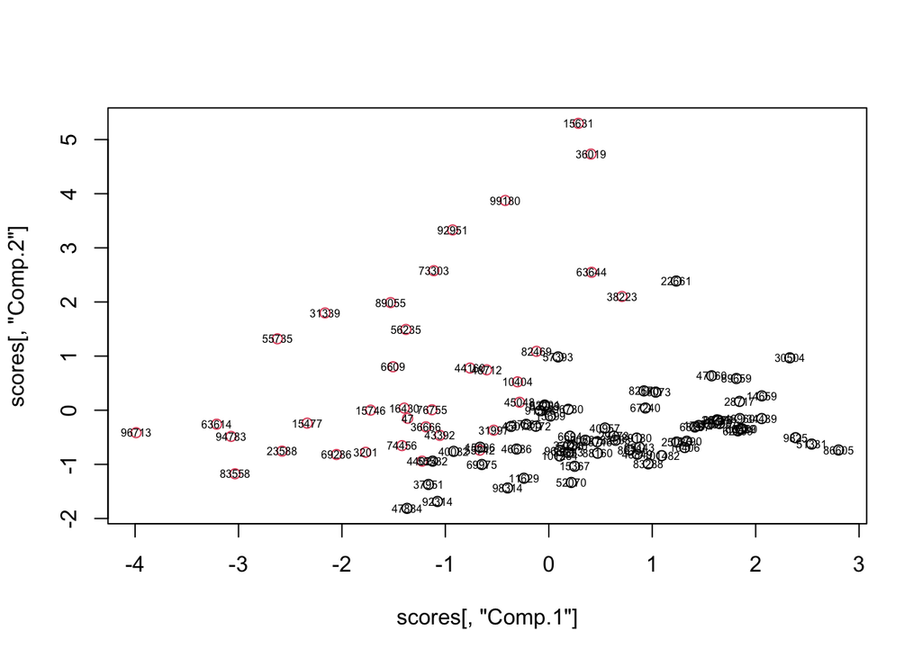

```r
 kmc <- kmeans(scaled_diabetes_data, centers = 2)

 # Perform PCA on the scaled data
pca_result <- princomp(scaled_diabetes_data)

# Get PCA scores
scores <- pca_result$scores[,1:2]
scores <- scores*-1

# Plot using qplot from ggplot2
plot(scores[, "Comp.1"], scores[,"Comp.2"], col=kmc$cluster)
text(scores[,"Comp.1"], scores[,"Comp.2"], labels=rownames(scaled_diabetes_data), cex=0.5)
```

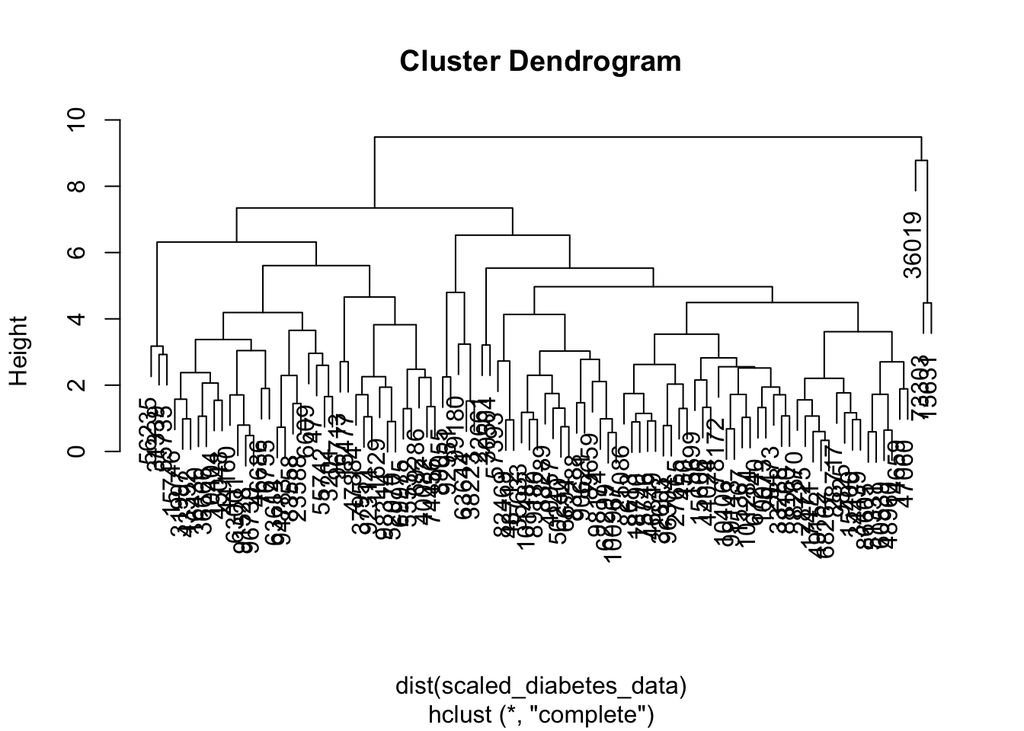

```r
hcf <- hclust(dist(scaled_diabetes_data))
  plot(hcf)
```

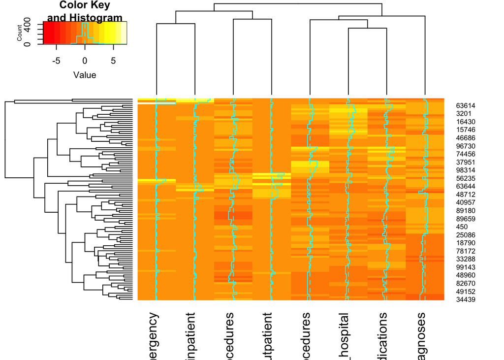

```r
heatmap.2(scaled_diabetes_data, scale="none")
```

```r
 dbc <- dbscan(scaled_diabetes_data,eps=2, MinPts=3)
  print(dbc)
```

```
## dbscan Pts=100 MinPts=3 eps=2
##         0  1
## border 18  2
## seed    0 80
## total  18 82
```

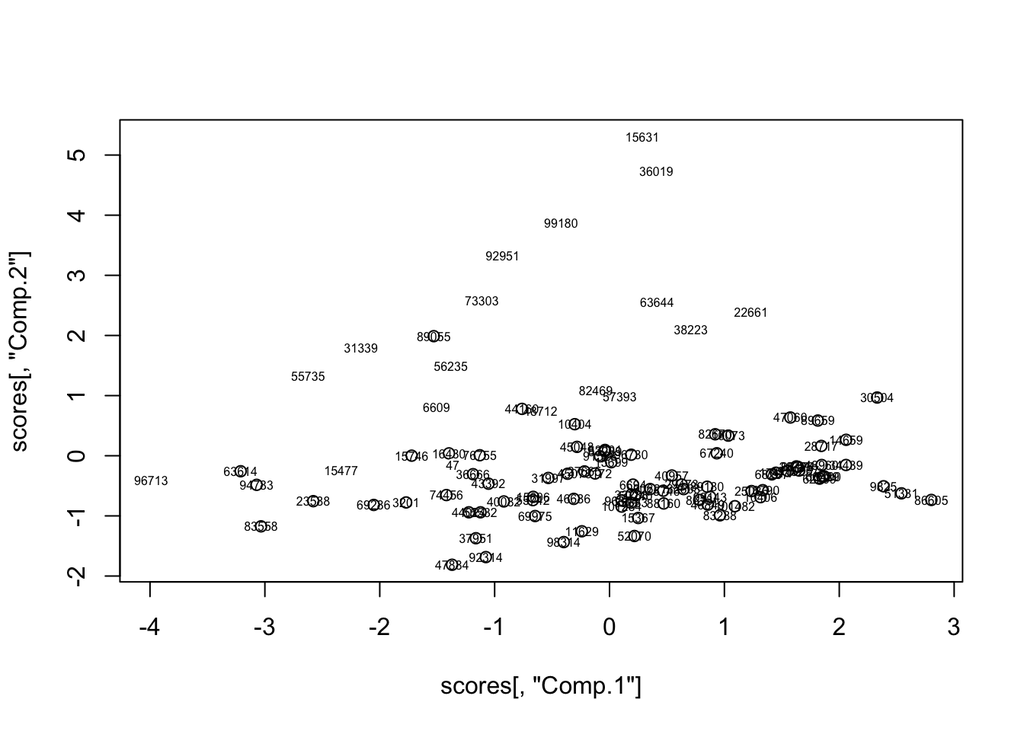

```r
 plot(scores[, "Comp.1"], scores[,"Comp.2"], col=dbc$cluster)
  text(scores[,"Comp.1"], scores[,"Comp.2"], labels=rownames(scaled_diabetes_data), cex=0.5)
```